# Palmetto binary logistic regression

Grace Kumaishi

1/31/2021

```r
# Read in the data:
palmetto <- read_csv(here("data/palmetto.csv"),
                     col_types = cols(.default = "c")) %>% # defaults all columns to character
  mutate(height = as.numeric(height)) %>% # mutate so that height is classified as numeric
  mutate(length = as.numeric(length)) %>%
  mutate(width = as.numeric(width)) %>%
  mutate(green_lvs = as.numeric(green_lvs)) %>%
  mutate(species_name = case_when(
    species == 1 ~ "Serenoa repens",
    species == 2 ~ "Sabal etonia"
  ))

# Make a subset of palmetto to simplify dataset
one_or_two <- palmetto %>%
  select(species, height:green_lvs) %>%
  mutate(species = as.factor(species))
```

### Exploratory data visualization:

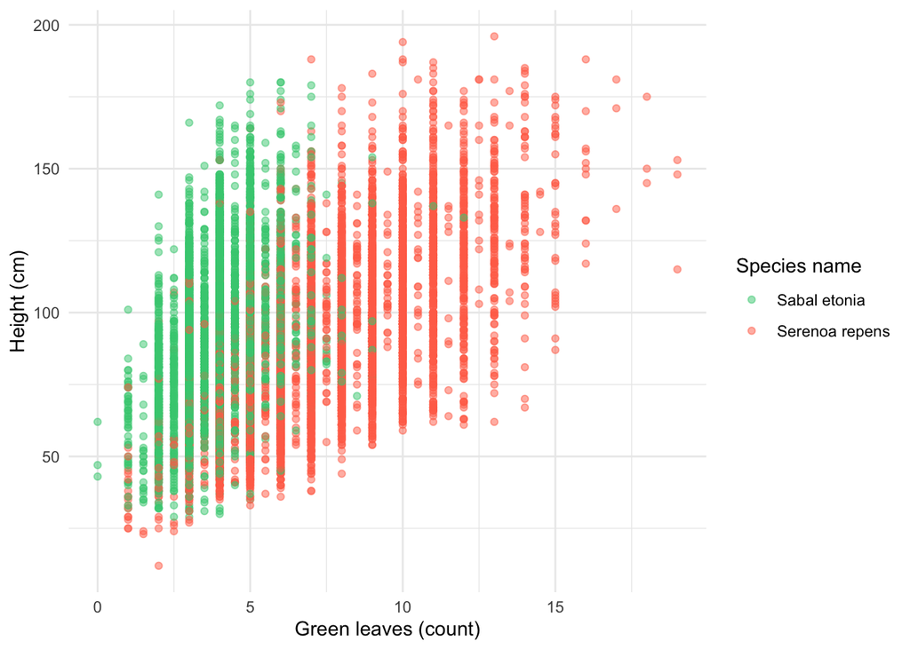

```r
ggplot(data = palmetto, aes(x = green_lvs, y = height, color = species_name)) +
  geom_point(alpha = .5) +
  scale_color_manual(values = c("seagreen3","coral1")) +
  labs(x = "Green leaves (count)",
       y = "Height (cm)",
       color = "Species name") +
  theme_minimal()
```

**Figure 1:** Scatterplot showing the relationship between green leaves counted and height (cm) of two palmetto species: *Sabal etonia* (shown here in green) and *Serenoa repens* (shown here in orange). (Data: Abrahamson, W.G. 2019).

**Takeaways:** *Serenoa repens* appears to have a larger range of green leaves counted when compared to *Sabal etonia*. There appears to be a positive relationship between height and green leaf count.

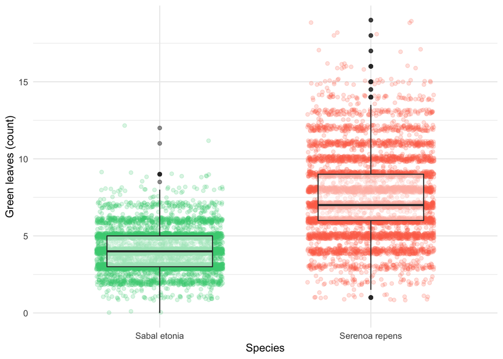

```r
ggplot() +
  geom_jitter(data = palmetto,
              aes(x = species_name, y = green_lvs, color = species_name),
              alpha = 0.2,
              width = 0.3) +
  scale_color_manual(values = c("seagreen3","coral1")) +
  geom_boxplot(data = palmetto,
             aes(x = species_name, y = green_lvs),
             width = 0.5,
             size = 0.5,
             alpha = 0.5) +
  labs(x = "Species",
       y = "Green leaves (count)") +
  theme_minimal() +
  theme(legend.position = "none")
```

**Figure 2:** A jitterplot overlaid with a boxplot to explore differences between the green leaves count of two palmetto species: *Sabal etonia* (shown here in green) and *Serenoa repens* (shown here in orange). Box endpoints indicate the 25<sup>th</sup> and 75<sup>th</sup> percentile values. The median value is indicated by a black line and the outliers are shown with black dots. (Data: Abrahamson, W.G. 2019).

**Takeaways:** This figure shows the difference in green leaf count between the two species. Again, *Serenoa repens* is shown to have a wider range of counts. *Sabal etonia* has consistently fewer leaves on average.

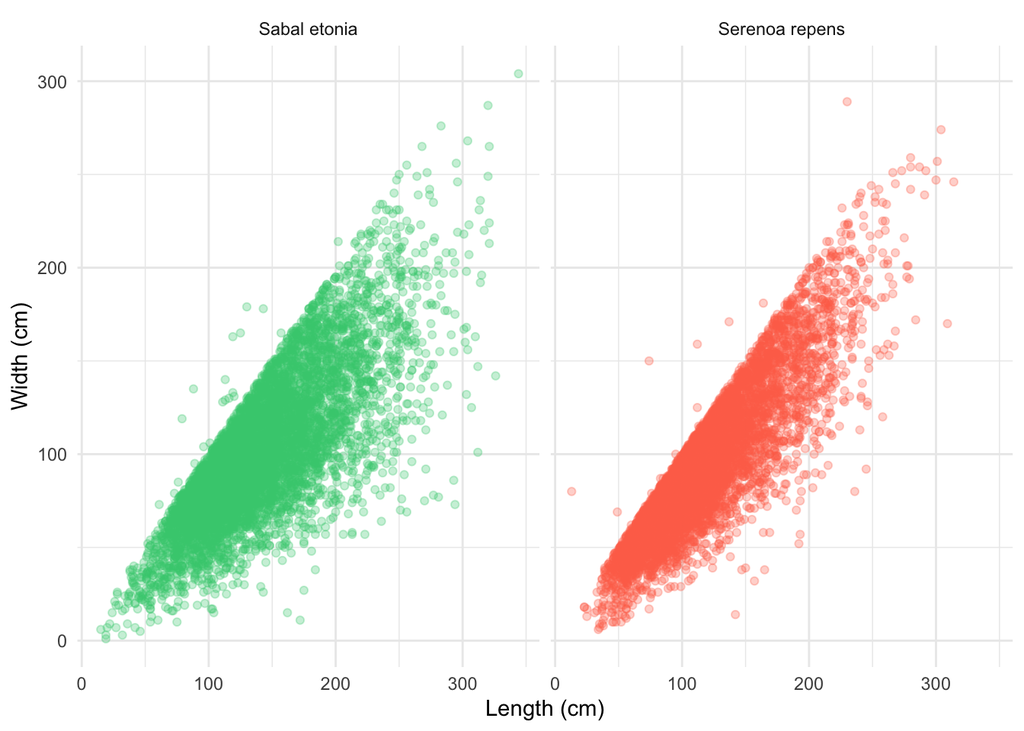

```r
ggplot(data = palmetto, aes(x = length, y = width, color = species_name)) +
  geom_point(alpha = .3) +
  facet_wrap(~species_name) +
  scale_color_manual(values = c("seagreen3","coral1")) +
  labs(x = "Length (cm)",
       y = "Width (cm)") +
  theme_minimal() +
  theme(legend.position = "none")
```

**Figure 3:** Scatterplot showing the relationship between canopy width (cm) and canopy length (cm) of two palmetto species: *Sabal etonia* (shown here in green) and *Serenoa repens* (shown here in orange). Plots are faceted due to similarity of data points. (Data: Abrahamson, W.G. 2019).

**Takeaways:** There does not appear to be much difference between the two species when comparing canopy length and canopy width. Both seem to follow a positive, perhaps linear relationship.

### Binary logistic regression:

```r
# Create blr:
palmetto_blr <- glm(species ~ height + length + width + green_lvs,
                            data = one_or_two,
                            family = "binomial")

# Look at the model:
# palmetto_blr
# summary(palmetto_blr)

# Get a tidy version w/ broom:
blr_tidy <- broom::tidy(palmetto_blr)

# Convert log odds to a probability:
blr_fitted <- palmetto_blr %>%
  broom::augment(type.predict = "response")

# Quick viz with green leaves:
quick_viz <- ggplot(data = blr_fitted, aes(x = green_lvs, y = .fitted)) +
  geom_point(aes(color = species)) +
  geom_smooth(aes(color = species), se = FALSE) +
  labs(x = "Green leaves",
       y = "Probability of outcome 2")

# Effect plot for green leaves:
# effect_plot(palmetto_blr,
            #pred = green_lvs,
            #interval = TRUE,
            #y.label = "Probability of '2'")
```

**Table 1:** Output of binary logistic regression using plant height, canopy length, canopy width, and green leaves as predictor variables to evaluate the probability of a plant being either *Serenoa repeons* or *Sabal etonia*. (Data: Abrahamson, W.G. 2019).

```r
stargazer(palmetto_blr, type = "html",
          title = "Binary Logistic Regression", # add title
          dep.var.labels = "Species 2 (Sabal entonia)", # add dependent variable
          covariate.labels = c("Height", "Length", "Width", "Green leaves")) # add covariate labels
```

**Binary Logistic Regression**

|  | *Dependent variable:* |
| --- | --- |
|  | Species 2 (Sabal entonia) |
| Height | -0.029*** |
|  | (0.002) |
| Length | 0.046*** |
|  | (0.002) |
| Width | 0.039*** |
|  | (0.002) |
| Green leaves | -1.908*** |
|  | (0.039) |
| Constant | 3.227*** |
|  | (0.142) |
| Observations | 12,267 |
| Log Likelihood | -2,592.281 |
| Akaike Inf. Crit. | 5,194.562 |
| *Note:* | p<0.1; p<0.05; p<0.01 |

### Finalized table:

```r
blr_fitted_new <- blr_fitted %>%
  select(species, .fitted) %>%
  mutate(predicted_sp = case_when( # calculate predicted outcome with a cutoff at 50%
    .fitted >= .5 ~ "2", # species 2 predicted at probabilities above 50%
    .fitted < .5 ~ "1")) %>%# species 1 predicted at probabilities below 50%
  mutate(classification = case_when( # create new column of correct and incorrect predictions
    species == predicted_sp ~ "Correct",
    species != predicted_sp ~ "Incorrect")) %>%
  group_by(species, classification) %>%
  count(classification) # count species correctly and incorrectly identified

blr_fitted_table <- blr_fitted_new %>%
  pivot_wider(names_from = classification, # pivot table
              values_from = n) %>%
  mutate(species = case_when(
    species == 1 ~ "Serenoa repens", # add species names
    species == 2 ~ "Sabal entonia")) %>%
  column_to_rownames(var = "species") # shift column so that species names are part of column 1

blr_fitted_table["Percent Correct"] = blr_fitted_table["Correct"] / (blr_fitted_table["Incorrect"] + blr_fitted_table["Correct"]) * 100 # add percentages in the last column of the table!
```

**Table 2:** Counts of “correct” and “incorrect” classifications of each species (*Serenoa repens* and *Sabal entonia*) using a binary logistic regression model with a 50% cutoff (i.e. anything over a probability of 50% is predicted as *Sabal entonia*). Percent of correct predictions is included. (Data: Abrahamson, W.G. 2019).

```r
kable(blr_fitted_table, digits = 2) %>% # round to two digits
  kable_styling(full_width = FALSE) %>% # remove full width default
  column_spec(1, italic = TRUE) # Italicize first column only
```

|  | Correct | Incorrect | Percent Correct |
| --- | --- | --- | --- |
| Serenoa repens | 5548 | 564 | 90.77 |
| Sabal entonia | 5701 | 454 | 92.62 |

### Citation:

[Abrahamson, W.G. 2019. Survival, growth and biomass estimates of two dominant palmetto species of south-central Florida from 1981 - 2017, ongoing at 5-year intervals ver 1. Environmental Data Initiative.](https://portal.edirepository.org/nis/mapbrowse?packageid=edi.317.1)